# Markup languages and the terminal—Power at your fingertips

Thomas de Graaff & Daniel Arribas-Bel

September 5, 2014

# Introduction

# Recap

Our main goal:

> To make our research as reproducable and visible as possible

This entails:

1. Sharing of code
2. Sharing of data (if possible and not proprietary nor privacy sensitive)
3. Sharing of output (presentation, article, website)

# The power of plain text

1. Ubiquitous
2. Usually small in size
3. Portable across platforms (and versions)
   - it will not be obsolote soon
   - everyone can read it everywhere
4. It is scriptable (both as input as output)
   - code is almost **always** in text format
   - **usually** data is in text format as well
   - but underlying format for output (presentation, website, tables, articles, books) **can** be text as well

# Manipulation of text

- Most output is based on simple text file; applications only change appearance, such as:
  - browsers
  - pdf
- **How** to change appearance require markup-languages
  - `HTML`
  - `LaTeX`
  - `Markdown`

# `Latex` and friends

# `LaTeX`

1. What?
   - A set of macros around `Tex`, a markup language invented by Donald Knuth
2. How?
   - Latex is a document preparation system and document markup language. [Source: Wikipedia](http://en.wikipedia.org/wiki/LaTeX)
3. Why?
   - Defacto standard in academic publishing
   - Formulae used in `HTML` pages (e.g., Wikipedia)
   - Macro’s thus scriptable (whoohoo)
4. But…
   - Notation a bit cumbersome
   - For small texts a bit too much and not geared for `HTML` [(see also)](http://yihui.name/en/2013/10/markdown-or-latex/)

# A minimal example

```latex
\documentclass[12pt]{article}
\begin{document}
\section{My Paper}
I just discovered that:
\begin{equation}
e=mc^2
\end{equation}
\end{document}
```

# Bibtex

- Basically a free reference manager (actually more a style of managing references)
- Very versatile and very powerful (most other markup languages work with bibtex as well)
- Free managers, such as bibdesk or mendeley, are now ubiquitous

# Markdown

# Why markdown?

1. Easy to learn http://daringfireball.net/projects/markdown/
2. Much less notation than Latex . Originally,
- `LaTeX` is for paper (aka dead trees)
- `Markdown` is for `HTML` (blogs, wikipedia and so)
- but sneakily uses some Latex when needed
3. Focus on text
4. Nowadays:
- ``easily’’ change it in html or pdf (via Latex)—even in Word if needed
- can be extended with code or—much better—its results

# Small diversion

> Question 1: Why and when do we make use of pdf’s and not html?

> Question 2: Is one always better than the other?

# Language syntax

Emphasis:

```markdown
*italic* **bold**
_italic_ __bold__
```

Headers:

```markdown
# Header 1
## Header 2
### Header 3
```

# Language syntax (cont.)

Unordened lists

```markdown
* Item 1
* Item 2
+ Item 2a
+ Item 2b
```

Ordered List

```markdown
1. Item 1
2. Item 2
3. Item 3
+ Item 3a
+ Item 3b
```

# Language syntax (cont.)

Links:

```markdown
http://assemble.io/docs/Cheatsheet-Markdown.html
[Cheatsheet](http://assemble.io/docs/Cheatsheet-Markdown.html)
```

Images:

```markdown
![alt text](http://example.com/logo.png)
![alt text](figures/img.png)
```

# Language syntax (cont.)

Code blocks:

```python
s = "Python syntax highlighting"
print s
```

# Language syntax (cont.)

To embed mathematics ‘just’ use [Latex notation](https://www.rpi.edu/dept/arc/training/latex/LaTeX_symbols.pdf):

```latex
$$e=mc^2$$
```

which surprisingly looks as excel type of formulae and renders as:

$e=mc^2$

# Language syntax (cont.)

Inline equations just require `$ $`, e.g.:

```latex
In economics it is well kwown that:
$\frac{d x}{d y} = -\frac{
\partial u(x,y)/ \partial y} {
\partial u(x,y)/ \partial x}$.
```

which renders as

In economics it is well kwown that: $\frac{d x}{d y} = -\frac{ \partial u(x,y)/ \partial y} { \partial u(x,y)/ \partial x}$.

# Pandoc

# The swiss knife of formats

So how do we glue everything together and produce wonderful htmls and pdfs out of thin air? With **[pandoc](http://johnmacfarlane.net/pandoc/)**

- Pandoc can convert from (not extensive):
- markdown (whoohoo), Latex, HTML, DocBook, Org-mode, and … Words docx
- To (and here we go…)
- HTML formats (including those very cool and nerdy HTML(5) slides)
- via Latex to pdf
- Word (but support somewhat limited) and OpenOffice formats
- various markup formats
- and much more

# So, a typical workflow in `R`

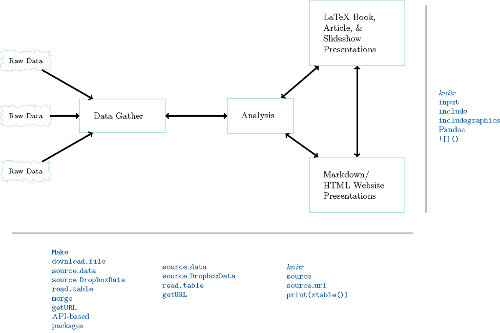

# The Assignment

# The assignment

- if not already done do:
- `git clone https://github.com/darribas/WooWii`
- go to `/WooWii/Paper/Assignment3/`
- and transform `RepPaper.txt` *as much as possible* in `RStudio`
- headers
- title + author
- reference (at least one is missing)
- footnotes
- table